# Graphics

### Agenda

- Grammer of Graphics
- Using ggplot2

The following presentation is based on the [ggplot2 tutorial](https://github.com/jennybc/ggplot2-tutorial) written by Prof. Jennifer Bryan.

### ggplot2 (wiki)

- ggplot2 is a data visualization package
- Created by Hadley Wickham in 2005
- ggplot2 is an implementation of Leland Wilkinson's Grammar of Graphics scheme
- ggplot2 has grown in use to become one of the most popular R packages.

### Grammar of Graphics

**Elments**

- `data`: The data that you want to visualise
- `aes`: Aesthetic mappings describing how variables in the data are mapped to aesthetic attributes
  - horizontalposition (`x`)
  - vertical position (`y`)
  - colour
  - size

### Grammar of Graphics

**Elments**

- `geoms`: Geometric objects that represent what you actually see on the plot
  - points
  - lines
  - polygons
  - bars

### Grammar of Graphics

**Elments**

- `stats`: Statistics transformations
  - binning and counting observations to create a histogram,
  - summarising a 2d relationship with a linear model
  - `stats` are optional

### Grammar of Graphics

**Elments**

- `scales`: related the data to the aesthetic
- `coord`: A coordinate systemthat describes how data coordinates are mapped to the plane of the graphic.
- `facet`: A faceting specification describes how to break up the data into subsets.

### Grammar of Graphics

**Layers**

A layer is composed of four parts:

- data and aesthetic mapping,
- a statistical transformation (`stat`),
- a geometric object (`geom`)
- a position adjustment.

A plot is constructed by adding layers to each other

### ggplot2

Load the library

```r
library(ggplot2)
```

Read data

```r
gdURL <- "http://tiny.cc/gapminder"
gDat <- read.table(file = gdURL,header=T,sep = "\t")
str(gDat)
```

```
'data.frame':   1698 obs. of  6 variables:
 $ country  : Factor w/ 147 levels "Afghanistan",..: 1 1 1 1 1 1 1 1 1 1 ...
 $ year     : int  1952 1957 1962 1967 1972 1977 1982 1987 1992 1997 ...
 $ pop      : num  8425333 9240934 10267083 11537966 13079460 ...
 $ continent: Factor w/ 5 levels "Africa","Americas",..: 3 3 3 3 3 3 3 3 3 3 ...
 $ lifeExp  : num  28.8 30.3 32 34 36.1 ...
 $ gdpPercap: num  779 821 853 836 740 ...
```

### Scatterplot

Creating a plot object

```r
p <- ggplot(gDat, aes(x = gdpPercap, y = lifeExp)) # just initializes
```

Scatterplot

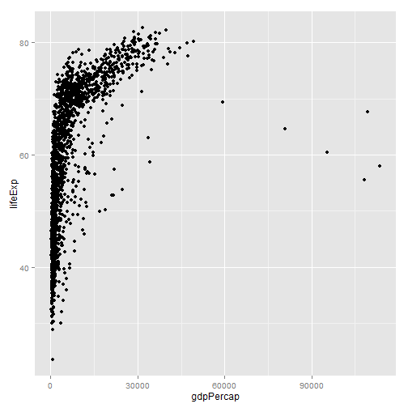

```r
p + geom_point()
```

```r
#p + layer(geom = "point")
```

### Data transformation

Log transformation … quick and dirty

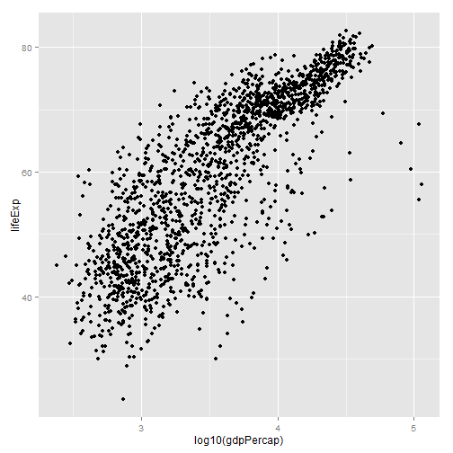

```r
ggplot(gDat, aes(x = log10(gdpPercap), y = lifeExp)) + geom_point()
```

### Data transformation

A better way to log transform

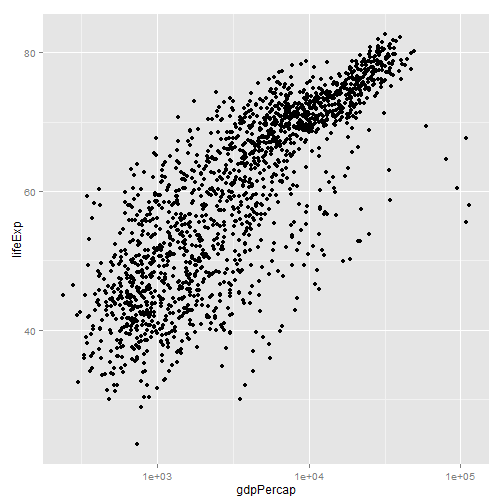

```r
p + geom_point() + scale_x_log10()
```

Let's make that stick

```r
p <- p + scale_x_log10()
```

common workflow: gradually build up the plot you want

Re-define the object `p` as you develop “keeper” commands

Convey continent by color: MAP continent variable to aesthetic color

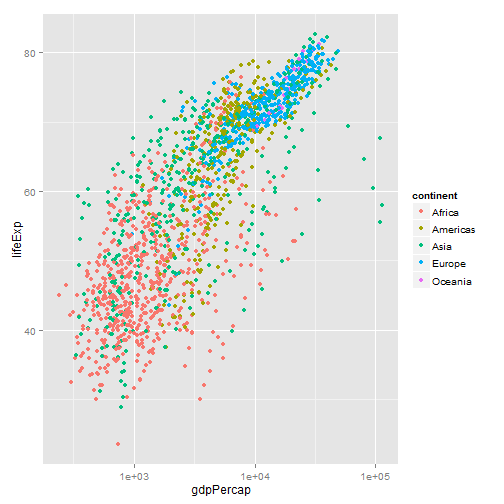

```r
p + geom_point(aes(color = continent))
```

In full detail, up to now:

```
ggplot(gDat, aes(x = gdpPercap, y = lifeExp, color = continent)) +
  geom_point() + scale_x_log10()
```

Address overplotting: SET alpha transparency and size to a value

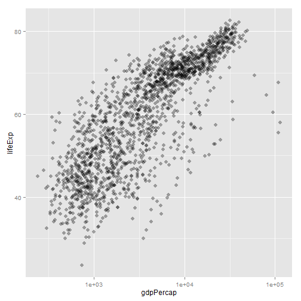

```r
p + geom_point(alpha = (1/3), size = 3)
```

### Curves

Add a fitted curve or line

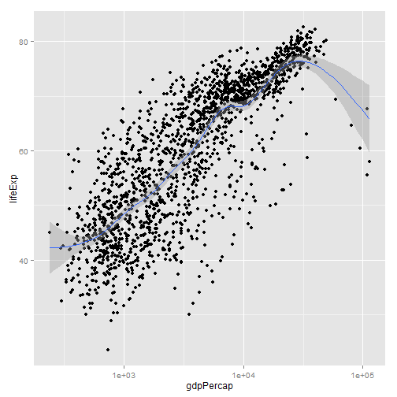

```r
p + geom_point() + geom_smooth()
```

### Curves

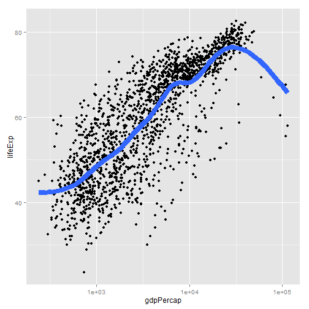

```r
p + geom_point() + geom_smooth(lwd = 3,
se = FALSE)
```

### Curves

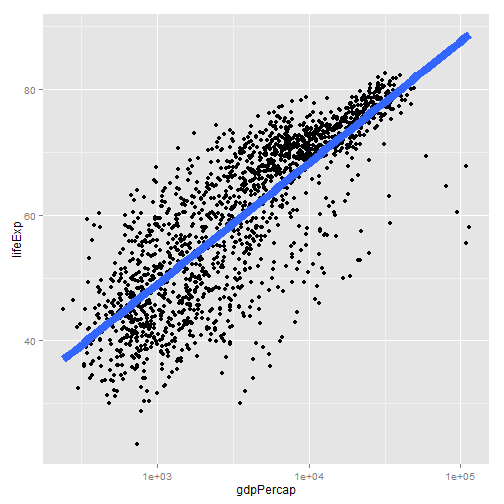

```r
p + geom_point() + geom_smooth(lwd = 3, se = FALSE, method = "lm")
```

### Curves

Return to continents:

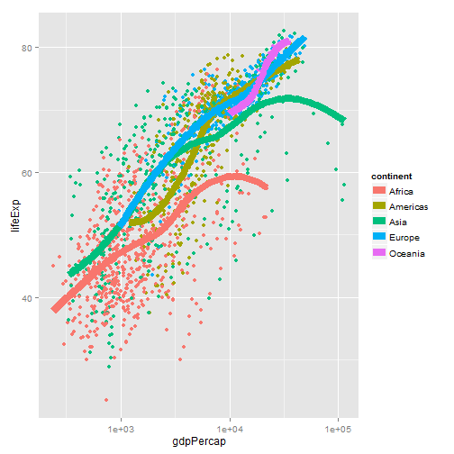

```r
p + aes(color = continent) + geom_point() + geom_smooth(lwd = 3, se = FALSE)
```

### Facets

Facetting: another way to exploit a factor

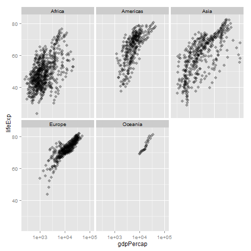

```r
p + geom_point(alpha = (1/3), size = 3) + facet_wrap(~ continent)
```

### Facets

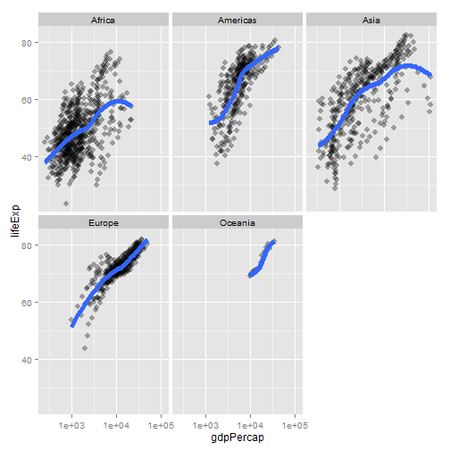

```r
p + geom_point(alpha = (1/3), size = 3) + facet_wrap(~ continent) +
  geom_smooth(lwd = 2, se = FALSE)
```

Exercises:

- Plot lifeExp against year
- Make mini-plots, split out by continent
- Add a fitted smooth and/or linear regression, with or without facetting

Plot `lifeExp` against `year`

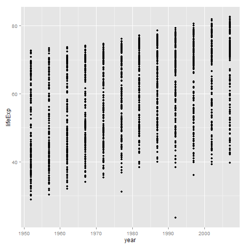

```r
(p1 <- ggplot(gDat, aes(x = year, y = lifeExp)) + geom_point())
```

Make mini-plots, split out by continent

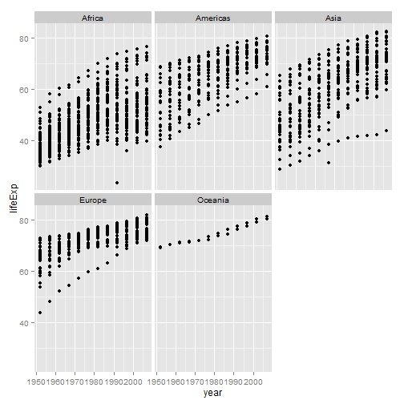

```r
p1 + facet_wrap(~ continent)
```

Add a fitted smooth and/or linear regression, without facetting

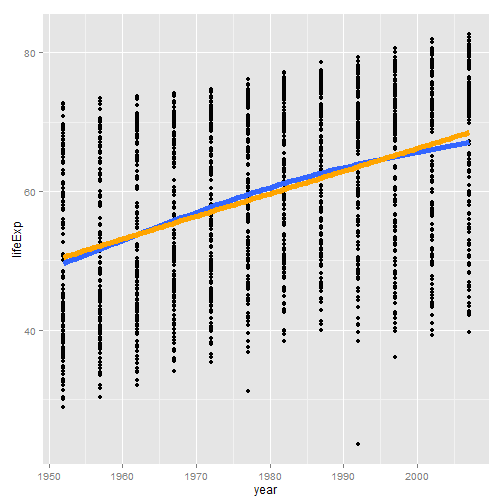

```r
p1 + geom_smooth(se = FALSE, lwd = 2) +
  geom_smooth(se = FALSE, method ="lm", color = "orange", lwd = 2)
```

Add a fitted smooth and/or linear regression, with facetting

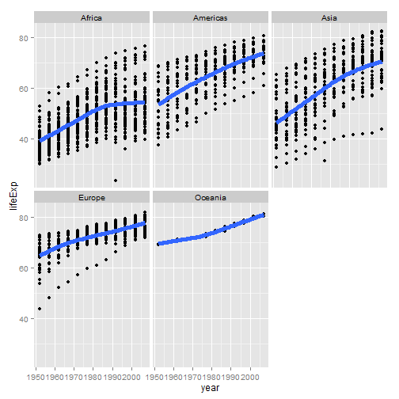

```r
p1+ geom_smooth(se = FALSE, lwd = 2) +
  facet_wrap(~ continent)
```

Last bit on scatterplots

- How can we “connect the dots” for one country? make a spaghetti plot?

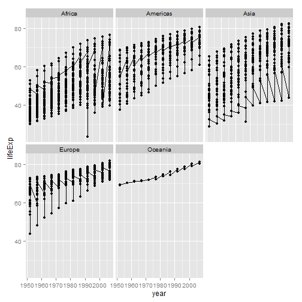

```r
p1 + facet_wrap(~ continent) + geom_line() # uh, no
```

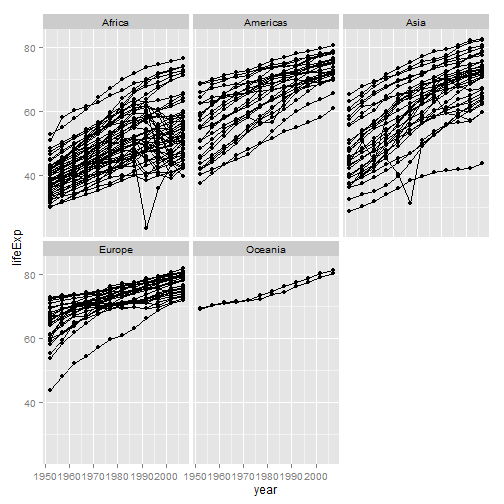

```r
p1 + facet_wrap(~ continent) + geom_line(aes(group = country)) # yes!
```

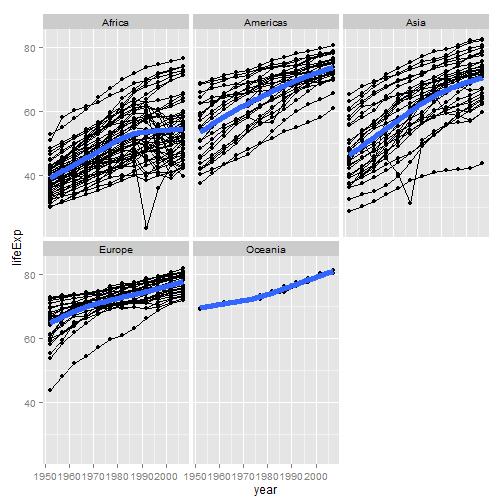

```r
p1 + facet_wrap(~ continent) + geom_line(aes(group = country)) +
  geom_smooth(se = FALSE, lwd = 2)
```

### Subsetting data

- `ggplot()` does not have a `subset =` argument
- Do that 'on the fly' with `subset(..., subset = ...)`

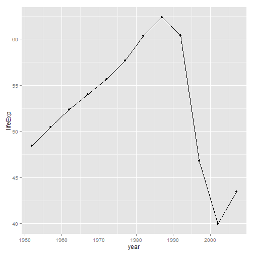

```r
ggplot(subset(gDat, country == "Zimbabwe"),
       aes(x = year, y = lifeExp)) + geom_line() + geom_point()
```

Let just look at four countries

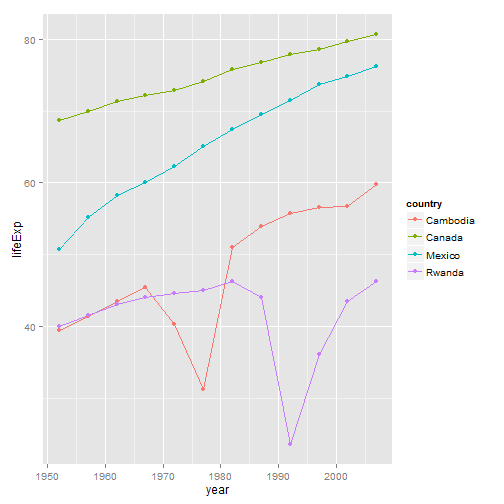

```r
jCountries <- c("Canada", "Rwanda", "Cambodia", "Mexico")
ggplot(subset(gDat, country %in% jCountries),
       aes(x = year, y = lifeExp, color = country)) + geom_line() + geom_point()
```

When you really care, make your legend easy to navigate

This means visual order = data order = factor level order

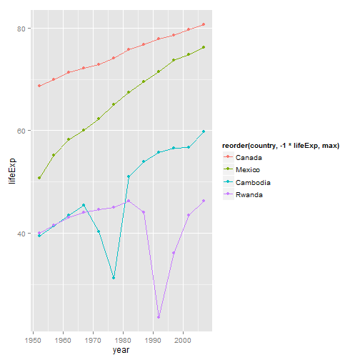

```r
ggplot(subset(gDat, country %in% jCountries),
       aes(x = year, y = lifeExp, color = reorder(country, -1 * lifeExp, max))) + geom_line() + geom_point()
```

Another approach to overplotting

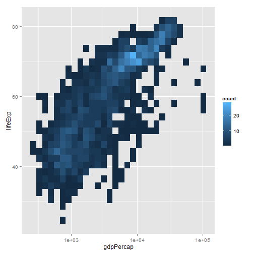

```r
ggplot(gDat, aes(x = gdpPercap, y = lifeExp)) + scale_x_log10() + geom_bin2d()
```

### Stripplots

Stripplots: univariate scatterplots (but w/ ways to also convey 1+ factors)

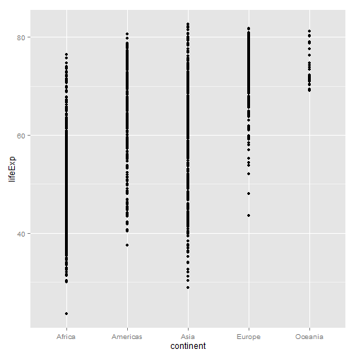

```r
ggplot(gDat, aes(x = continent, y = lifeExp)) + geom_point()
```

### Stripplots

We have an overplotting problem; need to spread things out

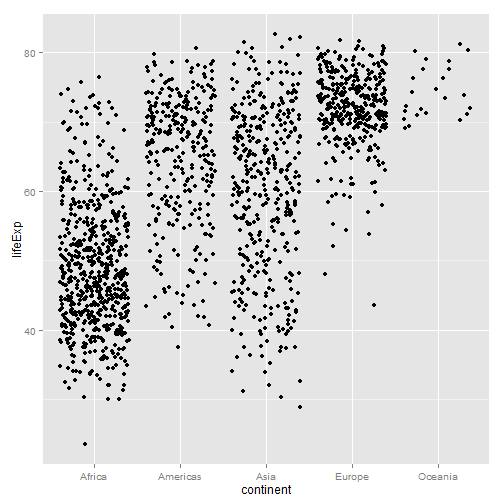

```r
ggplot(gDat, aes(x = continent, y = lifeExp)) + geom_jitter()
```

We can have less jitter in `x`, no jitter in `y`, more alpha transparency

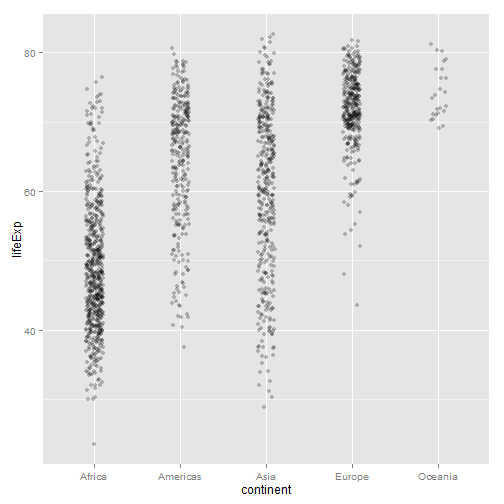

```r
ggplot(gDat, aes(x = continent, y = lifeExp)) +
  geom_jitter(position = position_jitter(width = 0.1, height = 0), alpha = 1/4)
```

### Boxplots

Boxplots – covered properly elsewhere

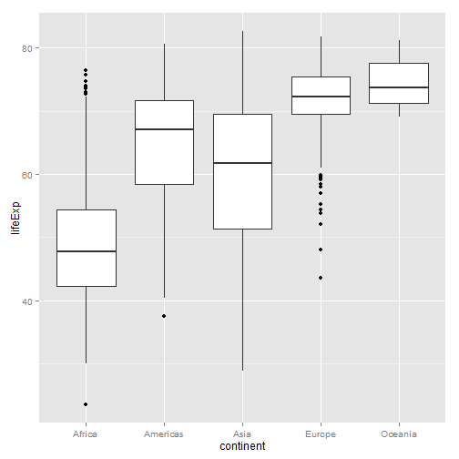

```r
ggplot(gDat, aes(x = continent, y = lifeExp)) + geom_boxplot()
```

### Boxplots

Raw data AND boxplots

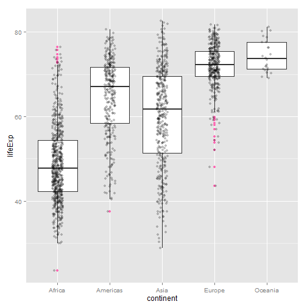

```r
ggplot(gDat, aes(x = continent, y = lifeExp)) +
  geom_boxplot(outlier.colour = "hotpink") +
  geom_jitter(position = position_jitter(width = 0.1, height = 0), alpha = 1/4)
```

Superpose a statistical summary

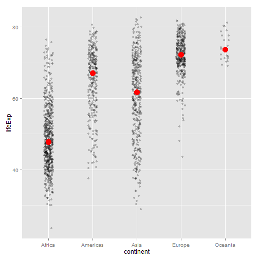

```r
ggplot(gDat, aes(x = continent, y = lifeExp)) +
  geom_jitter(position = position_jitter(width = 0.1), alpha = 1/4) +
  stat_summary(fun.y = median, colour = "red", geom = "point", size = 5)
```

Let's reorder the continent factor based on `lifeExp`

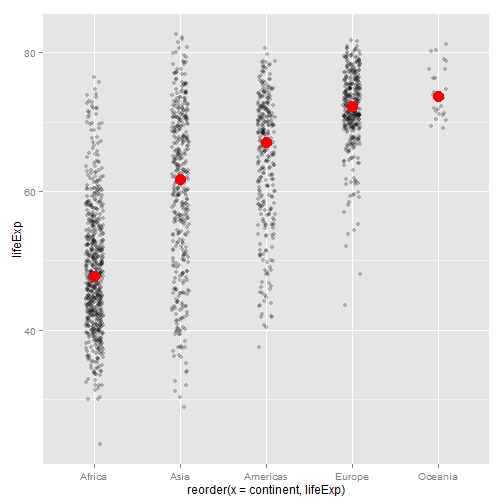

```r
ggplot(gDat, aes(reorder(x = continent, lifeExp), y = lifeExp)) +
  geom_jitter(position = position_jitter(width = 0.1), alpha = 1/4) +
  stat_summary(fun.y = median, colour = "red", geom = "point", size = 5)
```